# Bayesian Stats, Meeting 6

Adam Clark

2025-12-01

## “Confounders” in regression models

Today, we are going to work through some examples of “confounding” variables, as discussed by Richard McElreath in his lectures [here](https://www.youtube.com/watch?v=mBEA7PKDmiY&list=PLDcUM9US4XdPz-KxHM4XHt7uUVGWWVSus&index=6).

Below are a series of DAGs (“directional acyclic graphs”). These can be used to summarize qualitative information about the connections and directions by which causal information flows through a system. Depending on how these relationships are structured, different forms of analyses need to be applied to extract “correct” estimates of causal forcing.

Note - these corrections are both complicated, and exceedingly important! Implementing them carefully can give you vastly improved estimates of causal effects (even in experimental data!). Keep in the back of your head, though, that most of the corrections discussed here rest on the strong assumption that you model structure and all underlying equations are “correct”.

### The “Fork”

The fork describes cases where a single variable $Z$ causally “forces” (i.e. effects) two “response” variables $X$ and $Y$, which are not directly causally related to one another. This relationship can be summarised in the following DAG.

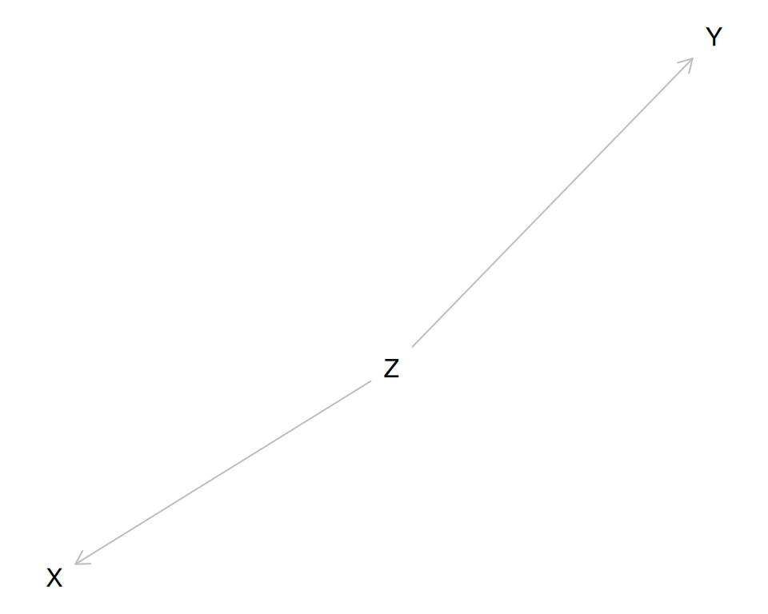

In this case, we will (incorrectly) assume that there is a relationship between $X$ and $Y$, unless we first control for $Z$. Consider the following simple linear example:

```r
n = 100
set.seed(232811)

Z = rnorm(n)
Y = rnorm(n) + 0.8*Z
X = rnorm(n) - 1.3*Z

plot(Y~X)
mod_F_YX = lm(Y~X)
summary(mod_F_YX)
```

```
##
## Call:
## lm(formula = Y ~ X)
##
## Residuals:
##      Min       1Q   Median       3Q      Max
## -2.52939 -0.67624  0.07554  0.69557  2.23488
##
## Coefficients:
##             Estimate Std. Error t value Pr(>|t|)
## (Intercept) -0.06996    0.10585  -0.661     0.51
## X           -0.35740    0.06623  -5.396 4.73e-07 ***
## ---
## Signif. codes:  0 '***' 0.001 '**' 0.01 '*' 0.05 '.' 0.1 ' ' 1
##
## Residual standard error: 1.025 on 98 degrees of freedom
## Multiple R-squared:  0.2291, Adjusted R-squared:  0.2212
## F-statistic: 29.12 on 1 and 98 DF,  p-value: 4.732e-07
```

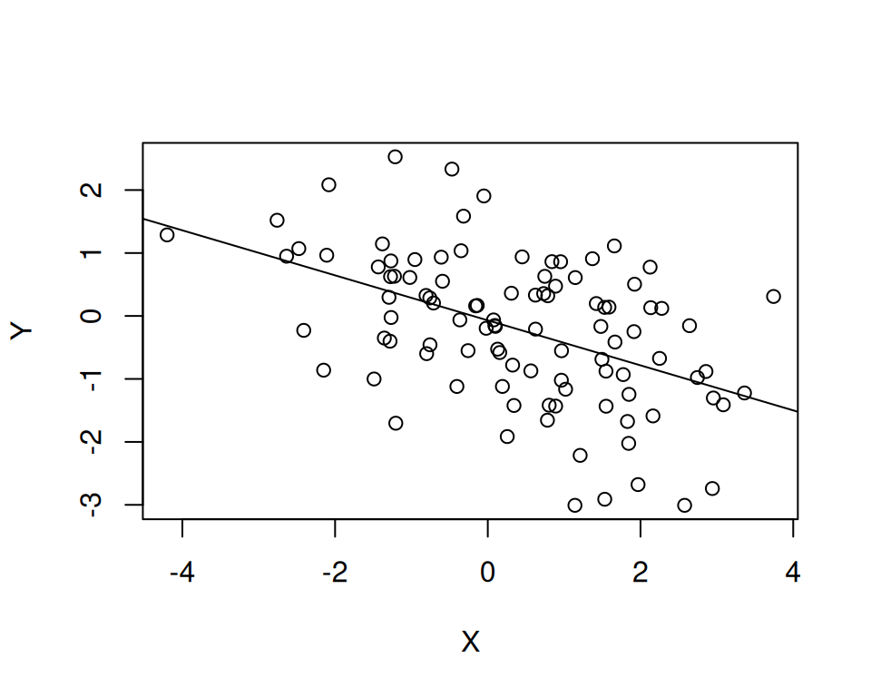

```r
abline(mod_F_YX)
```

To solve this problem, we first need to “control for” the effect of $Z$. For simple linear models, we can do this by regressing $X$ and $Y$ against Z, and then retaining their residuals, and conducting our analyses on these.

```r
mod_F_XZ = lm(X ~ Z)
mod_F_YZ = lm(Y ~ Z)

XresidZ = resid(mod_F_XZ)
YresidZ = resid(mod_F_YZ)

plot(YresidZ~XresidZ)
mod_F_AVP_XY = lm(YresidZ~XresidZ)
summary(mod_F_AVP_XY)
```

```
##
## Call:
## lm(formula = YresidZ ~ XresidZ)
##
## Residuals:
##     Min      1Q  Median      3Q     Max
## -2.4975 -0.7494  0.1324  0.5790  2.1595
##
## Coefficients:
##               Estimate Std. Error t value Pr(>|t|)
## (Intercept) -1.081e-17  9.439e-02   0.000    1.000
## XresidZ      2.591e-02  1.099e-01   0.236    0.814
##
## Residual standard error: 0.9439 on 98 degrees of freedom
## Multiple R-squared:  0.000567,   Adjusted R-squared:  -0.009631
## F-statistic: 0.0556 on 1 and 98 DF,  p-value: 0.8141
```

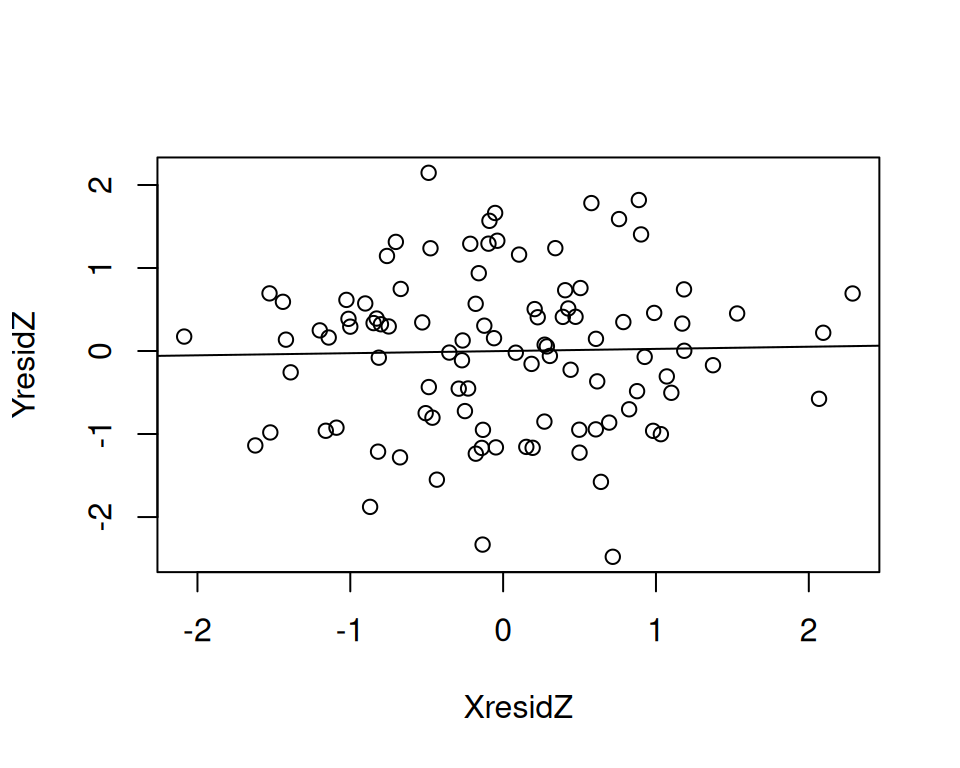

```r
abline(mod_F_AVP_XY)
```

This kind of plot is known as an “added variable plot” (AVP), and can be used to test whether a new predictor contains additional useful information for a multivariate regression (e.g. whether a regression predicting X from Z will benefit from additional information contained in Y). Here, we’ve shown that this is not the case - i.e. that $X$ and $Y$ share no variation other than that jointly driven by forcing variable $Z$.

We can also repeat this analysis using the “rethinking” package from McElreath:

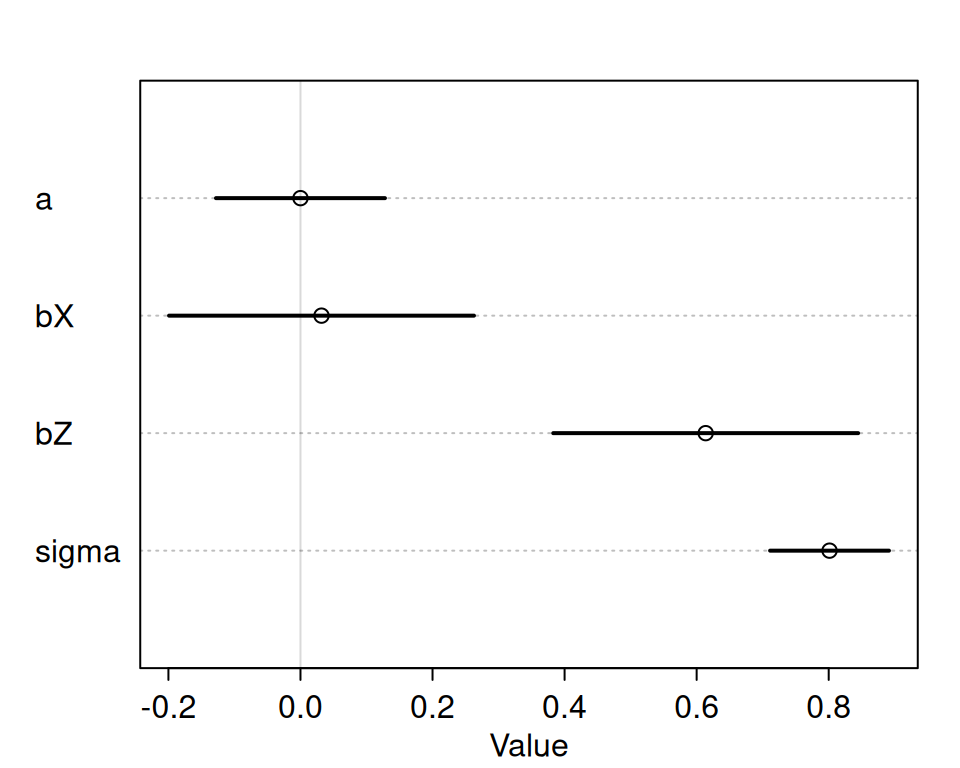

```r
require(rethinking)

# standardise data
dat <- list(
    X = standardize(X),
    Y = standardize(Y),
    Z = standardize(Z)
)

m_XYZ <- quap(
    alist(
        Y ~ dnorm(mu,sigma),
        mu <- a + bX*X + bZ*Z,
        a ~ dnorm(0,2), # priors
        bX ~ dnorm(0,2),
        bZ ~ dnorm(0,2),
        sigma ~ dexp(1)
    ) , data=dat )

plot(precis(m_XYZ))
```

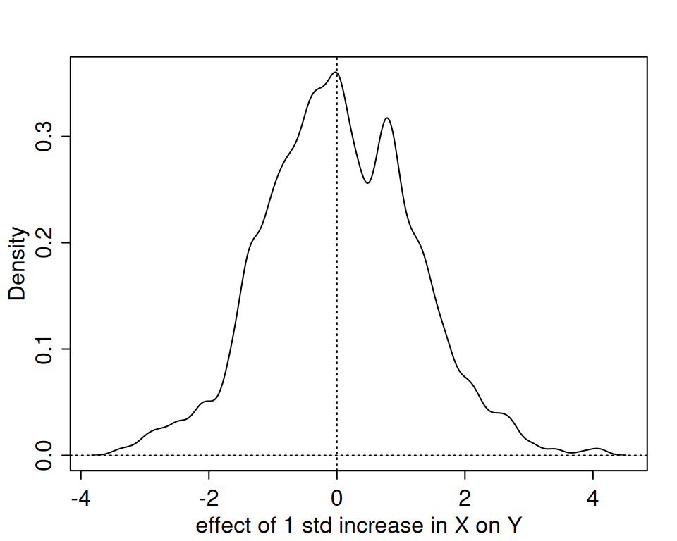

```r
post = extract.samples(m_XYZ) # extract estimates of parameters

# sample Z from data
niter = 1e3
Zs = sample(x = dat$Z, niter, rep = TRUE)

# simulate Y for hypothetical cases with X = 0
DY0 = with(post, rnorm(niter, a+bX*0+bZ*Zs, sigma))

# simulate Y for hypothetical case where X = 1 (1 std, since units are standardised)
# but using the same Z values
DY1 = with(post, rnorm(niter, a+bX*1+bZ*Zs, sigma))

# contrast and plot
Y10_contrast = DY1-DY0
dens(Y10_contrast, xlab = "effect of 1 std increase in X on Y")
abline(v = 0, h = 0, lty = 3)
```

#### Going old-school

One brief side-note: in theory, we could carry out something simlar to the Bayesain analysis by just fitting a multivariate linear regression:

```r
mod_F_YZX = lm(Y~Z+X)
summary(mod_F_YZX)
```

```
##
## Call:
## lm(formula = Y ~ Z + X)
##
## Residuals:
##     Min      1Q  Median      3Q     Max
## -2.4975 -0.7494  0.1324  0.5790  2.1595
##
## Coefficients:
##             Estimate Std. Error t value Pr(>|t|)
## (Intercept) -0.04209    0.09820  -0.429    0.669
## Z            0.73142    0.17535   4.171  6.6e-05 ***
## X            0.02591    0.11046   0.235    0.815
## ---
## Signif. codes:  0 '***' 0.001 '**' 0.01 '*' 0.05 '.' 0.1 ' ' 1
##
## Residual standard error: 0.9488 on 97 degrees of freedom
## Multiple R-squared:  0.3463, Adjusted R-squared:  0.3328
## F-statistic:  25.7 on 2 and 97 DF,  p-value: 1.109e-09
```

This model (corretly) finds no association between $X$ and $Y$. In general, this will work in most cases, though ordinary least squares can get a bit tricky when you have highly correlated predictors (e.g. as is the case with $X$ and $Z$) – technically, this is breaking one of the assumptions of OLS. The problem is that a wide range of potential parameter values all fit equally well - either “giving” the effect of shared variation to $X$. The paramters that end up chosen will be strongly determined by the way that random variation just happened to fall out in the sample of data that you are trying to analyse.

The advantage of optimisers used for Bayesian analyses is that they tend to estimate the full posterior distribution, meaning that it gives you average effect estimates across the full range of possible divisions of that variation. But this is definitely getting too deep in the weeds, so for now, just remember that the Bayesian parameter estimates (or things like the AVP analysis) will tend to be less biased if you structure your regression correctly.

### The “Pipe”

Next, we consider a case where a “mediator” variable $Z$ sits bewteen $X$ and $Y$ on a causal pathway, but does not directly influence variable $X$.

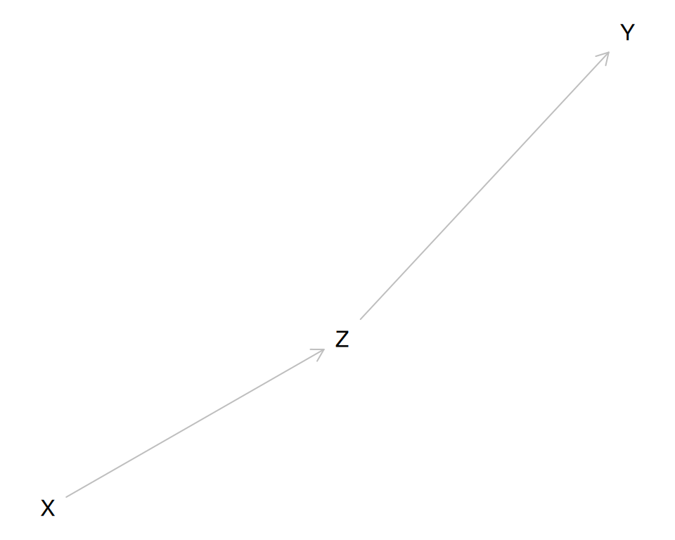

The problem here is that, although $X$ indirectly influences $Y$ via $Z$, there is no direct effect. And so, if we control for the effect of $Z$ while estimating the effect of $X$ on $Y$, we will fully remove this effect, and conclude that the two are not related.

In some cases, this can be a good thing – but not always. McElreath gives the example of $X$ as a fungicide treatment, $Z$ as a fungus, and $Y$ as plant growth. Here, the fungicide obviously (indirectly) influences plang growth, but because we can fully explain that effect based on the abundance of fungus, controlling for $Z$ will erase that effect, and cause us to (erroneously) conclude that the fungicide has no effect.

```r
n = 100

X = rep(c(0,1), each = n/2) # fungicide - 1 = yes, 2 = no
Z = rnorm(n, mean = 2) - X # fungus: negative effect of fungicide on fungus
Y = rnorm(n, mean = 5) - 0.8*Z # plant: negative effect of fungus on plant

# make the AVP
mod_P_XZ = lm(X ~ Z)
mod_P_YZ = lm(Y ~ Z)

XresidZ = resid(mod_P_XZ)
YresidZ = resid(mod_P_YZ)

plot(YresidZ~XresidZ)
mod_P_AVP_XY = lm(YresidZ~XresidZ)
summary(mod_P_AVP_XY)
```

```
##
## Call:
## lm(formula = YresidZ ~ XresidZ)
##
## Residuals:
##     Min      1Q  Median      3Q     Max
## -2.5619 -0.6060 -0.1602  0.5970  2.6245
##
## Coefficients:
##               Estimate Std. Error t value Pr(>|t|)
## (Intercept) -2.756e-18  1.018e-01    0.00    1.000
## XresidZ     -4.137e-02  2.427e-01   -0.17    0.865
##
## Residual standard error: 1.018 on 98 degrees of freedom
## Multiple R-squared:  0.0002965,  Adjusted R-squared:  -0.009905
## F-statistic: 0.02907 on 1 and 98 DF,  p-value: 0.865
```

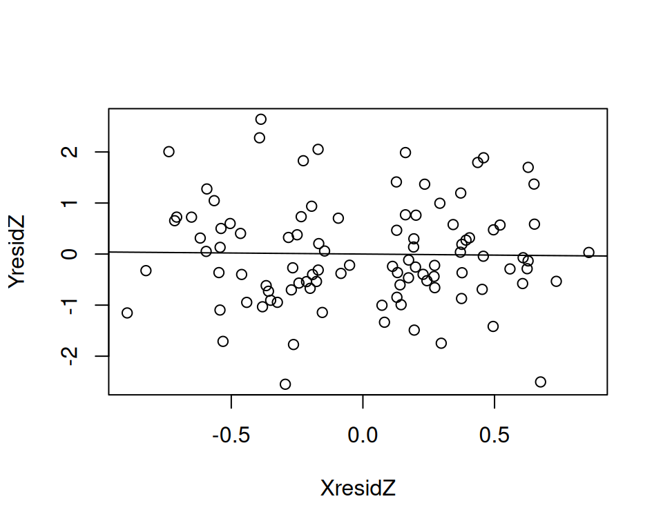

```r
abline(mod_P_AVP_XY)
```

The solution that he proposes is to simply ignore the variable $Z$ in our analysis.

```r
plot(Y~X)
mod_F_YX = lm(Y~X)
summary(mod_F_YX)
```

```
##
## Call:
## lm(formula = Y ~ X)
##
## Residuals:
##     Min      1Q  Median      3Q     Max
## -3.5263 -0.9330  0.0212  0.8244  3.2270
##
## Coefficients:
##             Estimate Std. Error t value Pr(>|t|)
## (Intercept)   3.2546     0.1788  18.199  < 2e-16 ***
## X             0.9203     0.2529   3.639 0.000439 ***
## ---
## Signif. codes:  0 '***' 0.001 '**' 0.01 '*' 0.05 '.' 0.1 ' ' 1
##
## Residual standard error: 1.265 on 98 degrees of freedom
## Multiple R-squared:  0.119,  Adjusted R-squared:   0.11
## F-statistic: 13.24 on 1 and 98 DF,  p-value: 0.0004395
```

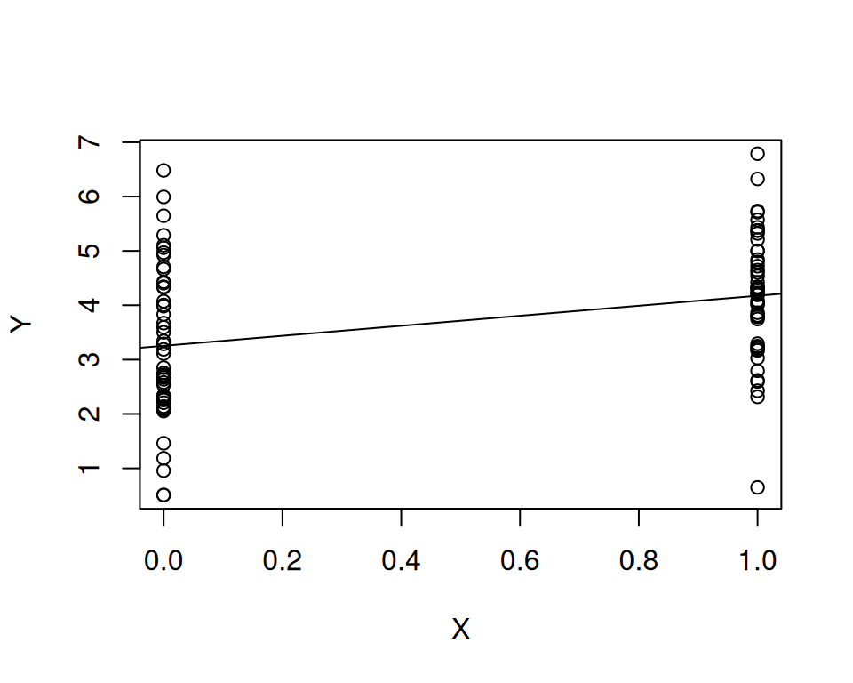

```r
abline(mod_F_YX)
```

This will leave us with a “total” causal effect of $X$ on $Y$ based on the indirect causal pathway through $Z$ – i.e. just use the regular old regression coefficient, showing a positive effect of fungicide on plant growth (or we can use the simulated contrast, as discussed above, for non-linear systems). For more details and code for this case, see the McElreath book.

### The “Collider”

The collider is a particularly pernicious case, where two variables $X$ and $Y$ jointly causally force shared variable $Z$, but do not interact directly.

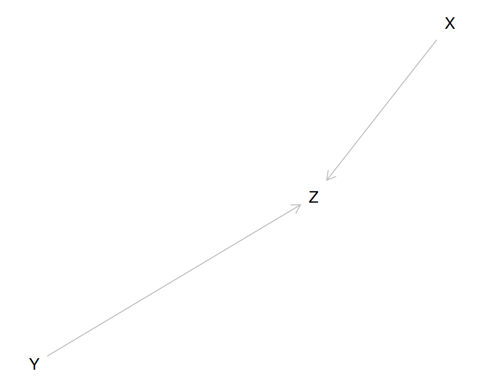

```r
n = 100

Y = rnorm(n)
X = rnorm(n)
Z = rnorm(n) + 0.9*X - 1.3*Y

mod_C_XZ = lm(X ~ Z)
mod_C_YZ = lm(Y ~ Z)

XresidZ = resid(mod_C_XZ)
YresidZ = resid(mod_C_YZ)

plot(YresidZ~XresidZ)
mod_C_AVP_XY = lm(YresidZ~XresidZ)
summary(mod_C_AVP_XY)
```

```
##
## Call:
## lm(formula = YresidZ ~ XresidZ)
##
## Residuals:
##     Min      1Q  Median      3Q     Max
## -1.2020 -0.3640  0.0093  0.4147  1.4071
##
## Coefficients:
##              Estimate Std. Error t value Pr(>|t|)
## (Intercept) 2.502e-17  5.721e-02   0.000        1
## XresidZ     4.267e-01  6.712e-02   6.357 6.54e-09 ***
## ---
## Signif. codes:  0 '***' 0.001 '**' 0.01 '*' 0.05 '.' 0.1 ' ' 1
##
## Residual standard error: 0.5721 on 98 degrees of freedom
## Multiple R-squared:  0.292,  Adjusted R-squared:  0.2847
## F-statistic: 40.41 on 1 and 98 DF,  p-value: 6.542e-09
```

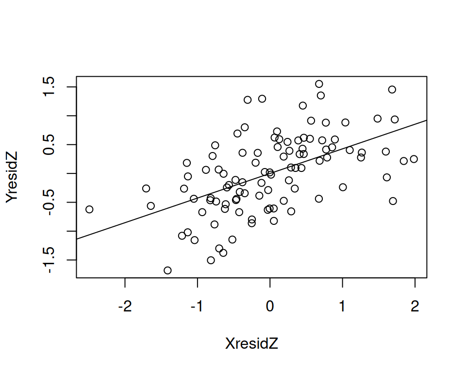

```r
abline(mod_C_AVP_XY)
```

The collider will even fool a fancy Bayesian model!

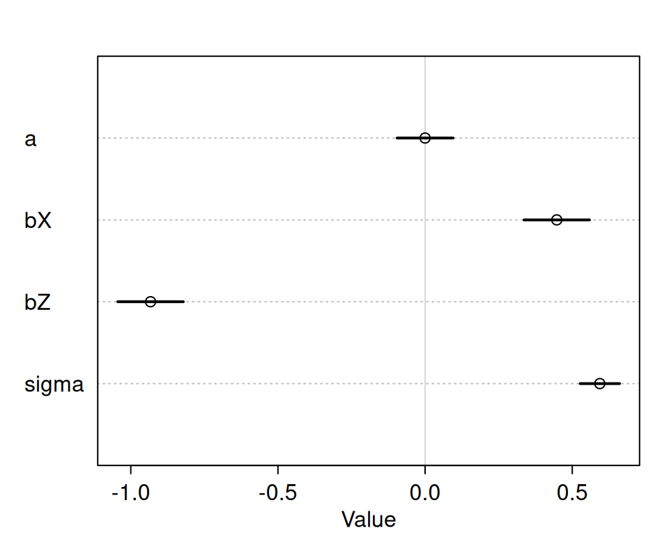

```r
# standardise data
dat <- list(
    X = standardize(X),
    Y = standardize(Y),
    Z = standardize(Z)
)

m_XYZ <- quap(
    alist(
        Y ~ dnorm(mu,sigma),
        mu <- a + bX*X + bZ*Z,
        a ~ dnorm(0,2), # priors
        bX ~ dnorm(0,2),
        bZ ~ dnorm(0,2),
        sigma ~ dexp(1)
    ) , data=dat )

plot(precis(m_XYZ))
```

On the other hand, if we simply test the the link between $X$ and $Y$ without including $Z$, the problem goes away, and we “correctly” find that there is no relationship between them. Again, the solution is to *not* control for $Z$ in your analyses.

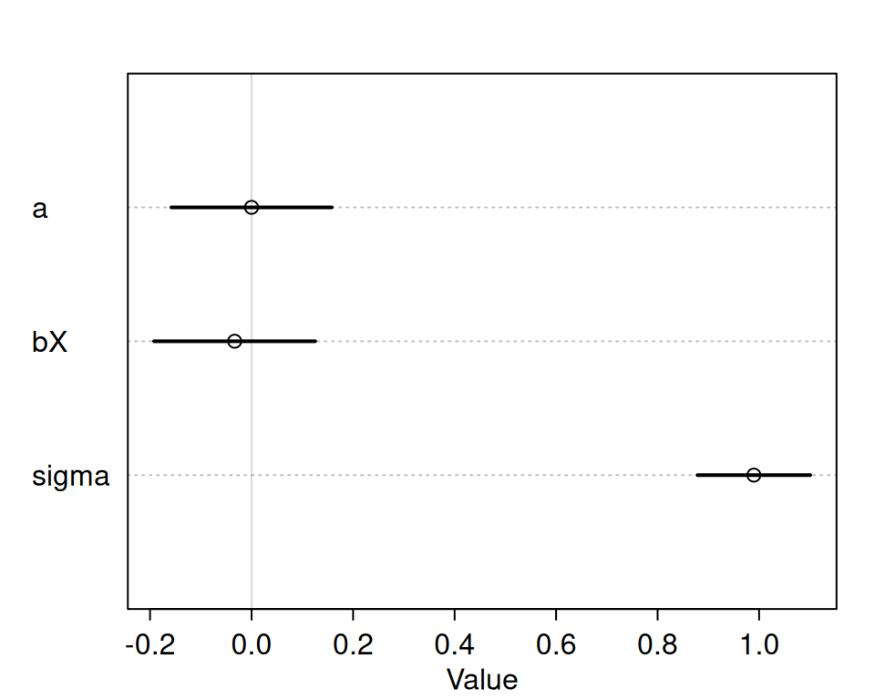

```r
m_XYZ <- quap(
    alist(
        Y ~ dnorm(mu,sigma),
        mu <- a + bX*X,
        a ~ dnorm(0,2), # priors
        bX ~ dnorm(0,2),
        sigma ~ dexp(1)
    ) , data=dat )

plot(precis(m_XYZ))
```

A nice real-world example relates to the common complaint that good books are always turned into bad movies. The link to colliders is from McElreath’s lecture, though the example itself is from a great YouTube video from Numberphile – link [here](https://www.youtube.com/watch?v=FUD8h9JpEVQ).

Let’s first assume that there is no relationship at all between book and movie qualitiy. It’s all just luck of the draw. So, if we plot their qualities against eachother, you get:

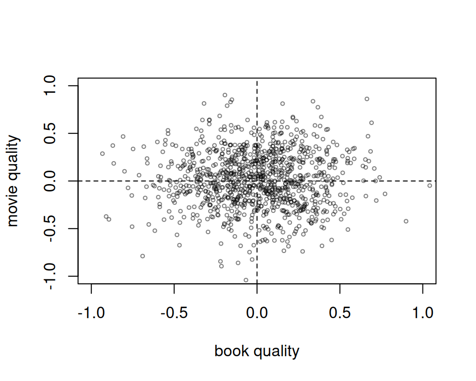

Now, let’s admit that we aren’t super well-read. So, we only know about good books. If a bad book happens to be turned into a movie, we might still like the movie, but we probably won’t know that it was adapted from a book in the first place. This means that much of the left side of the plot becomes invisible to us.

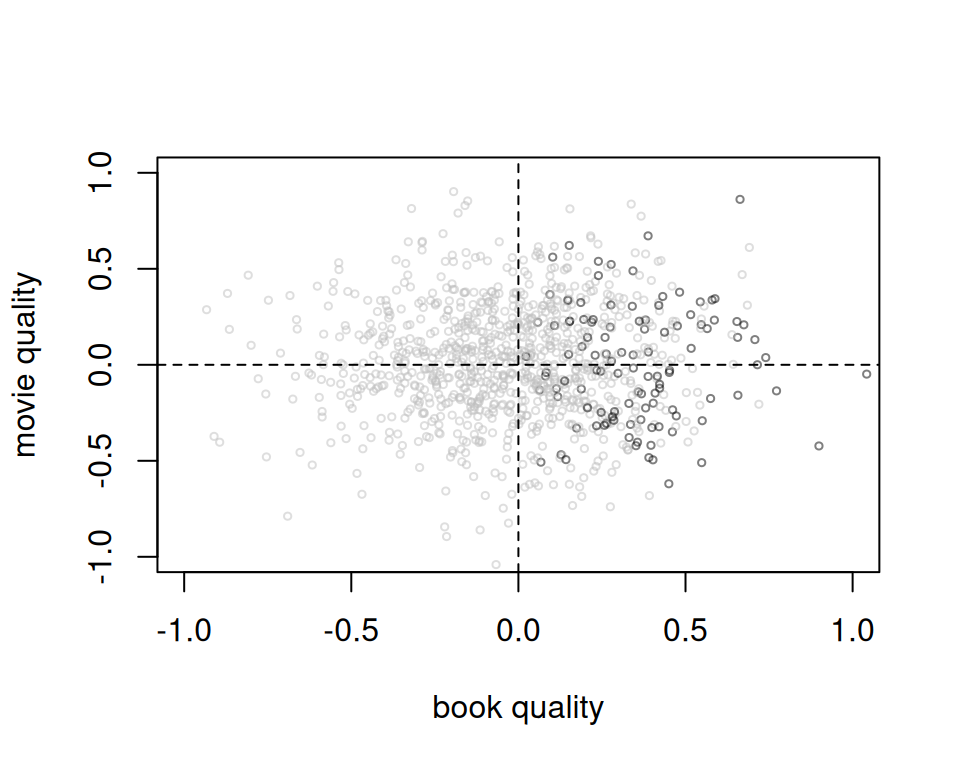

Finally, let’s admit that we don’t actually watch that many movies either. Really, we only go to super popular ones, which means that we are much more likely to see “good” movies than “bad” movies. That leaves us with:

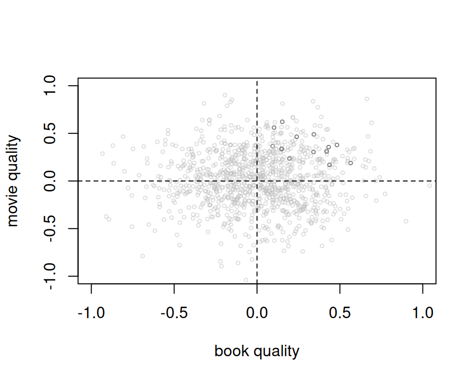

Now, if we fit a regression to just the movies that we have watched that we know are based on books, we find (to our horror) that there is indeed a negative correlation between the two!

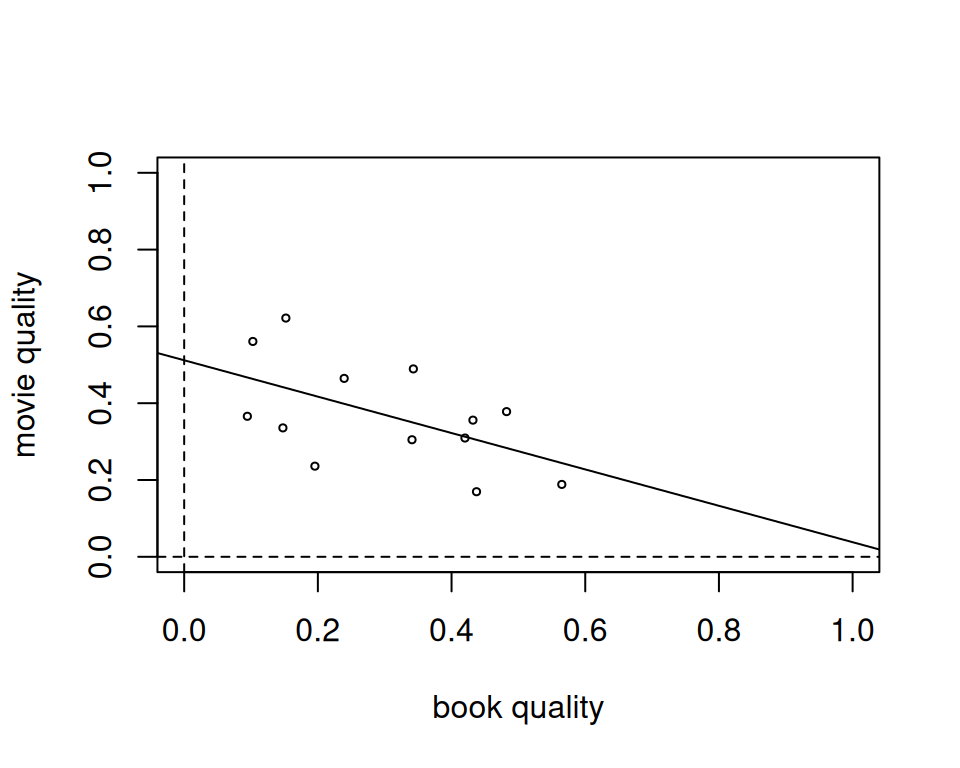

This is because, even though movie quality and book quality are not related, we are jointly “controlling” for them based on our knowledge and choices (and thse are indeed impacted by the book and movie quality). McElreath notes that there are lots of similar cases that relate to post-selection controls in experiments – the short answer is that these are basically always a bad idea.

### The “Descendant”

McElreath describes the descendant as a “parasite” on the other kinds of confounders (and luckily a relatively simple one to control for).

The basic idea is that we have a variable $A$ that is causally forced by $Z$, but not related to the other variables that we are trying to analyse. This can occur for any of the cases listed above, but as an example with a pipe set-up:

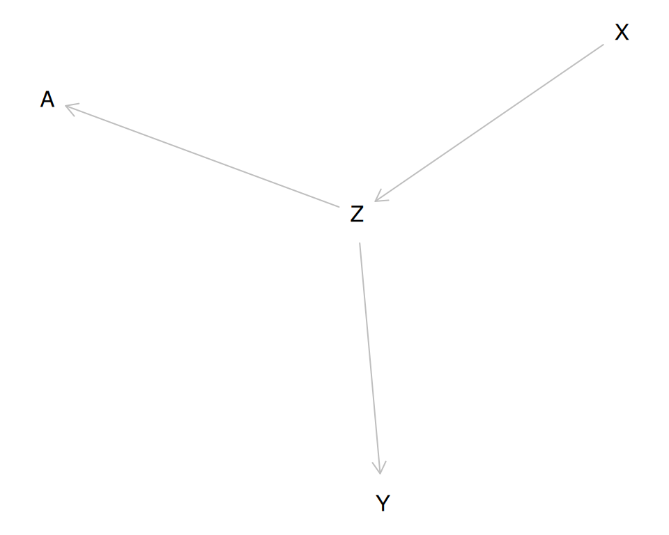

The result is effectively that $A$ inherits some of the problems that $Z$ causes in trying to estimate causal effects. For example, if we try to condition on $A$ in this analysis:

```r
n = 100

X = rep(c(0,1), each = n/2) # fungicide - 1 = yes, 2 = no
Z = rnorm(n, mean = 2) - X # fungus: negative effect of fungicide on fungus
Y = rnorm(n, mean = 5) - 0.8*Z # plant: negative effect of fungus on plant
A = rnorm(n, mean = 2) - 0.5*Z # ladybug: is negatively impacted by fungus, but doesn't hurt plants

# make the AVP, conditioning on A
mod_D_XA = lm(X ~ A)
mod_D_YA = lm(Y ~ A)

XresidA = resid(mod_D_XA)
YresidA = resid(mod_D_YA)

plot(YresidA~XresidA)
mod_D_AVP_XY = lm(YresidZ~XresidZ)
summary(mod_D_AVP_XY)
```

```
##
## Call:
## lm(formula = YresidZ ~ XresidZ)
##
## Residuals:
##     Min      1Q  Median      3Q     Max
## -1.2020 -0.3640  0.0093  0.4147  1.4071
##
## Coefficients:
##              Estimate Std. Error t value Pr(>|t|)
## (Intercept) 2.502e-17  5.721e-02   0.000        1
## XresidZ     4.267e-01  6.712e-02   6.357 6.54e-09 ***
## ---
## Signif. codes:  0 '***' 0.001 '**' 0.01 '*' 0.05 '.' 0.1 ' ' 1
##
## Residual standard error: 0.5721 on 98 degrees of freedom
## Multiple R-squared:  0.292,  Adjusted R-squared:  0.2847
## F-statistic: 40.41 on 1 and 98 DF,  p-value: 6.542e-09
```

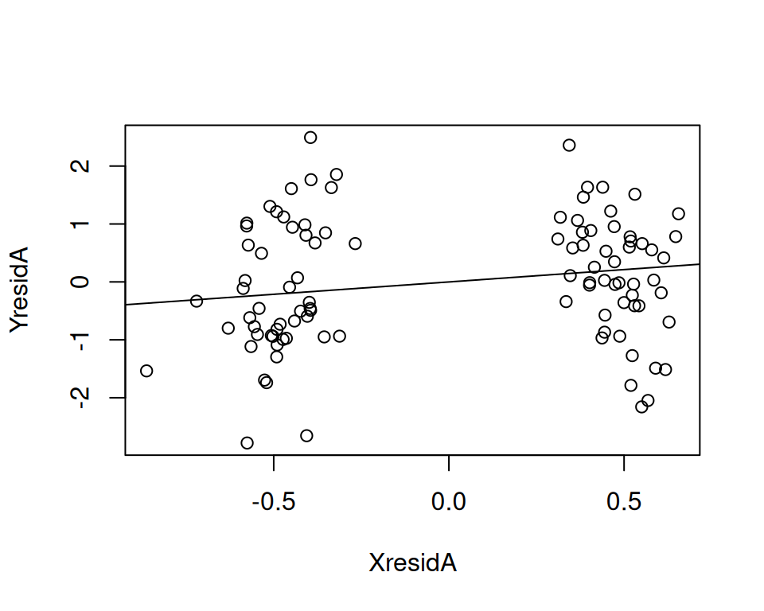

```r
abline(mod_D_AVP_XY)
```

we find that like $Z$, it removes (some of) the association between fungicide and plant growth, even though we are only conditioning on ladybug abundance. This is a very, very common problem in multiple regression – i.e. we very often end up with things that are correlated with other variables in our models. And so, you really need to think very hard about what variables to include in your regression, what to control for, and what to leave out.

### Bonus: Model misspecification

Model misspecification is a case that is not directly considered by McElreath in his lecture on confounders, though he alludes to the problem frequently in his lectures and book. The general idea is a case like:

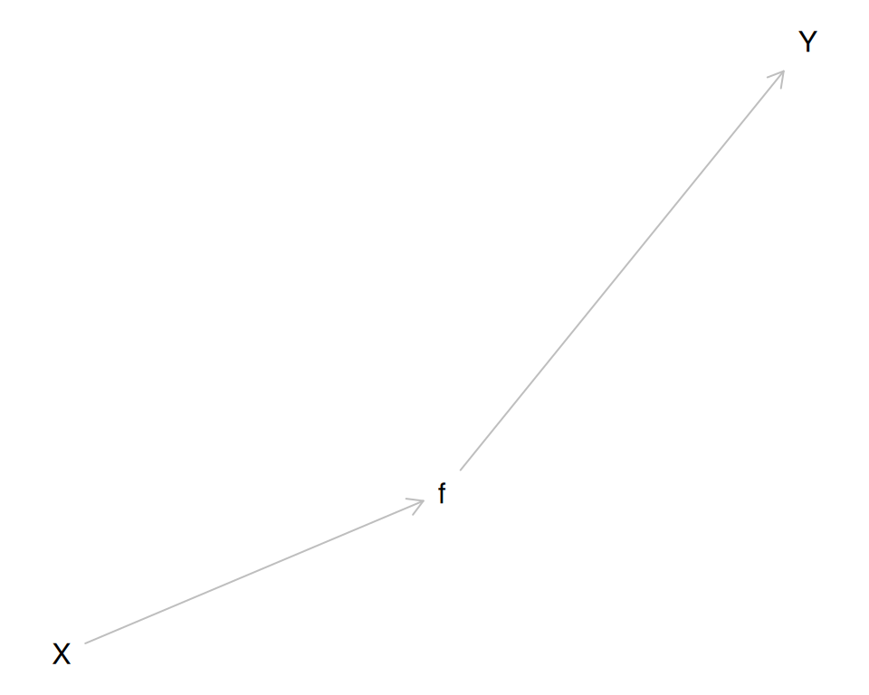

where $f$ is some complex nonlinear function of $X$ - e.g. $sin(X)$. Somewhat obviously, if we try to fit model coefficinets for this using a simple linear model, we run into trouble.

```r
X = seq(0, 11*pi, length=n)
Y = sin(X)

plot(Y~X, type = "l")

mod_nL = lm(Y~X)
summary(mod_nL)
```

```
##
## Call:
## lm(formula = Y ~ X)
##
## Residuals:
##      Min       1Q   Median       3Q      Max
## -1.04152 -0.69950 -0.05671  0.58607  0.92809
##
## Coefficients:
##               Estimate Std. Error t value Pr(>|t|)
## (Intercept)  5.671e-02  1.406e-01   0.403    0.688
## X           -9.366e-18  7.030e-03   0.000    1.000
##
## Residual standard error: 0.7084 on 98 degrees of freedom
## Multiple R-squared:  4.382e-32,  Adjusted R-squared:  -0.0102
## F-statistic: 4.294e-30 on 1 and 98 DF,  p-value: 1
```

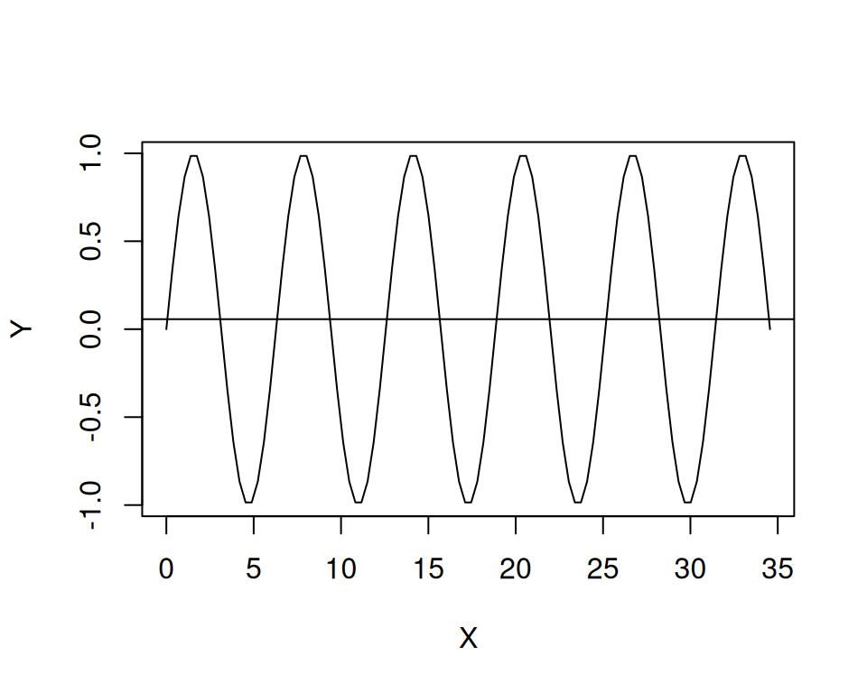

```r
abline(mod_nL)
```

Here, we end up with a slope estimate of almost exactly zero, and no significant relationships detected – even though there is clearly a relationship between $X$ and $Y$.

This is a general warning about applying these kinds of causal inference approaches. The first step before any of them can be used (or indeed, before any kind of regression can be applied) is to think very, very hard about the functional forms underlying the data in your system, and about the causal associations that connect them. To me, this first step really is the most important and exciting part of science – it’s where we make hypotheses about how the world works, and put them into quantitatively rigorous forms. The regressions and analyses are still important, but at the end of the day, they are just book-keeping to try to tease out the numbers that are implied by our hypotheses.

### Next week:

What we do next week will depend a bit on your interests. We could continue with this set of ideas, and work through the next video from MacElreath, which focuses on other kinds of solutions. Link is [here](https://www.youtube.com/watch?v=uanZZLlzKHw&list=PLDcUM9US4XdPz-KxHM4XHt7uUVGWWVSus&index=7).

However, we can also work on other problems or methods that you’d like to discuss – e.g. extensions of the nlme function for nonlinear data (e.g. growth dynamics and weighting routines), or we could dig deeper into informative priors.

Remember that next week is our last meeting before Christmas break. Our meetings in January will be online (though if I am back early enough, I’ll try to also have an in-person option available). The point of these meetings is to help you carry out an analysis using the methods that we’ve discussed in this course, which you need to turn in as your “final assignment” for the class.